# sanjay_19_dec_2021

```python
from sklearn.datasets import load_boston
import pandas as pd
import numpy as np
import seaborn as sns
import matplotlib.pyplot as plt
import statsmodels.api as sm
from sklearn.model_selection import train_test_split,GridSearchCV
from sklearn.linear_model import LinearRegression
from sklearn import metrics
from sklearn.metrics import mean_squared_error,roc_auc_score,roc_curve,classification_report,confusion_matrix,plot_confusion_matrix
from statsmodels.stats.outliers_influence import variance_inflation_factor
import math
plt.rc("font", size=14)
import seaborn as sns
sns.set(style="white")
sns.set(style="whitegrid", color_codes=True)

from sklearn.discriminant_analysis import LinearDiscriminantAnalysis
```

### 1.1. Read the data and do exploratory data analysis. Describe the data briefly. (Check the null values, Data types, shape, EDA, duplicate values). Perform Univariate and Bivariate Analysis.

```python
df = pd.read_csv("cubic_zirconia.csv")
df.head()
```

|  | Unnamed: 0 | carat | cut | color | clarity | depth | table | x | y | z | price |
| --- | --- | --- | --- | --- | --- | --- | --- | --- | --- | --- | --- |
| 0 | 1 | 0.30 | Ideal | E | SI1 | 62.1 | 58.0 | 4.27 | 4.29 | 2.66 | 499 |
| 1 | 2 | 0.33 | Premium | G | IF | 60.8 | 58.0 | 4.42 | 4.46 | 2.70 | 984 |
| 2 | 3 | 0.90 | Very Good | E | VVS2 | 62.2 | 60.0 | 6.04 | 6.12 | 3.78 | 6289 |
| 3 | 4 | 0.42 | Ideal | F | VS1 | 61.6 | 56.0 | 4.82 | 4.80 | 2.96 | 1082 |
| 4 | 5 | 0.31 | Ideal | F | VVS1 | 60.4 | 59.0 | 4.35 | 4.43 | 2.65 | 779 |

```python
df.dtypes
```

```
Unnamed: 0      int64
carat         float64
cut            object
color          object
clarity        object
depth         float64
table         float64
x             float64
y             float64
z             float64
price           int64
dtype: object
```

```python
df.shape
```

```
(26967, 11)
```

```python
df.describe()
```

|  | Unnamed: 0 | carat | depth | table | x | y | z | price |
| --- | --- | --- | --- | --- | --- | --- | --- | --- |
| count | 26967.000000 | 26967.000000 | 26270.000000 | 26967.000000 | 26967.000000 | 26967.000000 | 26967.000000 | 26967.000000 |
| mean | 13484.000000 | 0.798375 | 61.745147 | 57.456080 | 5.729854 | 5.733569 | 3.538057 | 3939.518115 |
| std | 7784.846691 | 0.477745 | 1.412860 | 2.232068 | 1.128516 | 1.166058 | 0.720624 | 4024.864666 |
| min | 1.000000 | 0.200000 | 50.800000 | 49.000000 | 0.000000 | 0.000000 | 0.000000 | 326.000000 |
| 25% | 6742.500000 | 0.400000 | 61.000000 | 56.000000 | 4.710000 | 4.710000 | 2.900000 | 945.000000 |
| 50% | 13484.000000 | 0.700000 | 61.800000 | 57.000000 | 5.690000 | 5.710000 | 3.520000 | 2375.000000 |
| 75% | 20225.500000 | 1.050000 | 62.500000 | 59.000000 | 6.550000 | 6.540000 | 4.040000 | 5360.000000 |
| max | 26967.000000 | 4.500000 | 73.600000 | 79.000000 | 10.230000 | 58.900000 | 31.800000 | 18818.000000 |

```python
df.info()
```

```
<class 'pandas.core.frame.DataFrame'>
RangeIndex: 26967 entries, 0 to 26966
Data columns (total 11 columns):
Unnamed: 0    26967 non-null int64
carat         26967 non-null float64
cut           26967 non-null object
color         26967 non-null object
clarity       26967 non-null object
depth         26270 non-null float64
table         26967 non-null float64
x             26967 non-null float64
y             26967 non-null float64
z             26967 non-null float64
price         26967 non-null int64
dtypes: float64(6), int64(2), object(3)
memory usage: 2.3+ MB
```

###### From Info, we can infer that depth has some null values in it.

```python
df.isnull().sum()
```

```
Unnamed: 0      0
carat           0
cut             0
color           0
clarity         0
depth         697
table           0
x               0
y               0
z               0
price           0
dtype: int64
```

```python
(df.isnull().sum()/ len(df))*100
```

```
Unnamed: 0    0.00000
carat         0.00000
cut           0.00000
color         0.00000
clarity       0.00000
depth         2.58464
table         0.00000
x             0.00000
y             0.00000
z             0.00000
price         0.00000
dtype: float64
```

From this we can infer, 2.6 % of depth has null values.

```python
dups = df.duplicated()
print('Number of duplicate rows = %d' % (dups.sum()))
```

```
Number of duplicate rows = 0
```

```python
for column in df.columns:
    if df[column].dtype == 'object':
        print(column.upper(),': ',df[column].nunique())
        print(df[column].value_counts().sort_values())
        print('\n')
```

```
CUT :  5
Fair           781
Good          2441
Very Good     6030
Premium       6899
Ideal        10816
Name: cut, dtype: int64


COLOR :  7
J    1443
I    2771
D    3344
H    4102
F    4729
E    4917
G    5661
Name: color, dtype: int64


CLARITY :  8
I1       365
IF       894
VVS1    1839
VVS2    2531
VS1     4093
SI2     4575
VS2     6099
SI1     6571
Name: clarity, dtype: int64
```

```python
df[['carat' ,'depth', 'table', 'x', 'y', 'z','price']].nunique()
```

```
carat     257
depth     169
table     112
x         531
y         526
z         356
price    8742
dtype: int64
```

### Univariate Analysis

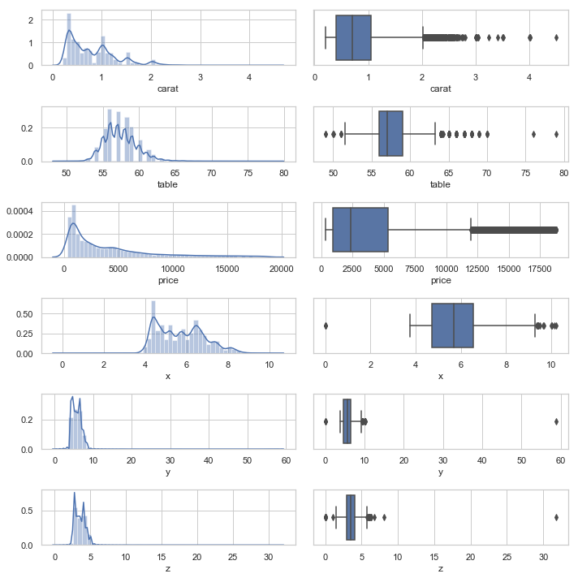

```python
fig, axes = plt.subplots(nrows=6,ncols=2)
fig.set_size_inches(10,10)
sns.distplot(df['carat'], kde=True, ax=axes[0][0])
sns.boxplot(x='carat', data=df, ax=axes[0][1])
sns.distplot(df['table'] , kde=True, ax=axes[1][0])
sns.boxplot(x='table', data=df , ax=axes[1][1])
sns.distplot(df['price'] , kde=True, ax=axes[2][0])
sns.boxplot(x='price', data=df , ax=axes[2][1])
sns.distplot(df['x'], kde=True, ax=axes[3][0])
sns.boxplot(x='x', data=df, ax=axes[3][1])
sns.distplot(df['y'] , kde=True, ax=axes[4][0])
sns.boxplot(x='y', data=df , ax=axes[4][1])
sns.distplot(df['z'] , kde=True, ax=axes[5][0])
sns.boxplot(x='z', data=df , ax=axes[5][1])
plt.tight_layout()
plt.show()
```

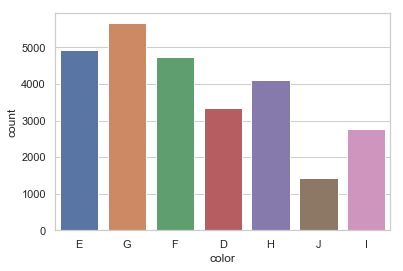

```python
sns.countplot(df["color"])
```

### Bi-Variate Analysis

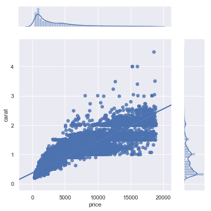

```python
sns.set(style="darkgrid", color_codes=True)
sns.jointplot(df["price"],df["carat"],kind="reg")
plt.tight_layout()
plt.show()
```

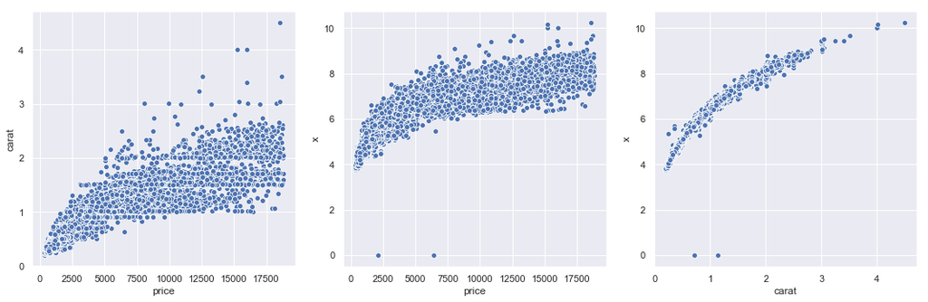

```python
fig, axes = plt.subplots(nrows=1,ncols=3)
fig.set_size_inches(15,5)
# plt.figure(figsize=(12,7))
sns.scatterplot(df['price'], df['carat'], ax=axes[0])
sns.scatterplot(df['price'], df['x'], ax=axes[1])
sns.scatterplot(df['carat'], df['x'], ax=axes[2])
plt.tight_layout()
plt.show()
```

### Multi-Variate Analysis

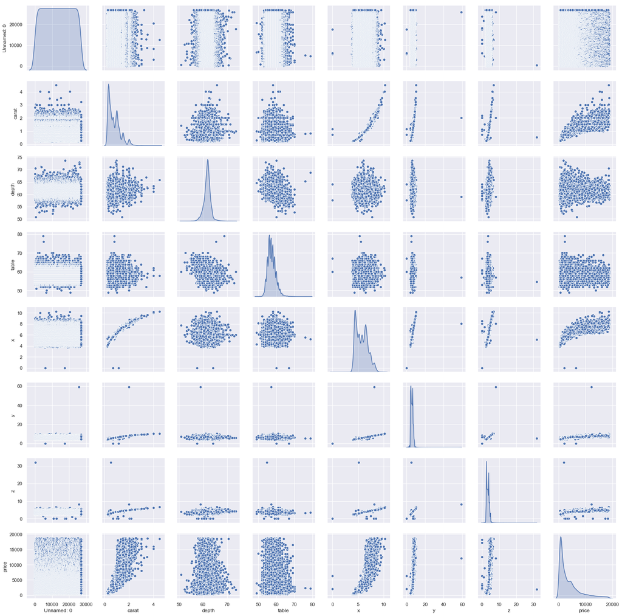

```python
sns.pairplot(df,diag_kind="kde")
```

```python
df.corr()
```

|  | Unnamed: 0 | carat | depth | table | x | y | z | price |
| --- | --- | --- | --- | --- | --- | --- | --- | --- |
| Unnamed: 0 | 1.000000 | 0.003490 | -0.001588 | 0.003817 | 0.004626 | 0.006844 | 0.001681 | 0.002650 |
| carat | 0.003490 | 1.000000 | 0.035364 | 0.181685 | 0.976368 | 0.941071 | 0.940640 | 0.922416 |
| depth | -0.001588 | 0.035364 | 1.000000 | -0.298011 | -0.018715 | -0.024735 | 0.101624 | -0.002569 |
| table | 0.003817 | 0.181685 | -0.298011 | 1.000000 | 0.196206 | 0.182346 | 0.148944 | 0.126942 |
| x | 0.004626 | 0.976368 | -0.018715 | 0.196206 | 1.000000 | 0.962715 | 0.956606 | 0.886247 |
| y | 0.006844 | 0.941071 | -0.024735 | 0.182346 | 0.962715 | 1.000000 | 0.928923 | 0.856243 |
| z | 0.001681 | 0.940640 | 0.101624 | 0.148944 | 0.956606 | 0.928923 | 1.000000 | 0.850536 |
| price | 0.002650 | 0.922416 | -0.002569 | 0.126942 | 0.886247 | 0.856243 | 0.850536 | 1.000000 |

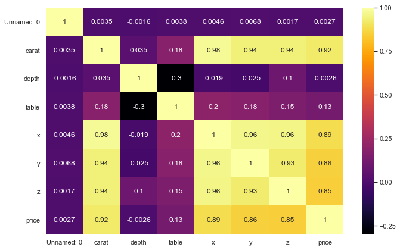

```python
plt.figure(figsize=(10,6))
sns.heatmap(df.corr(),annot=True,cmap='inferno')
plt.tight_layout()
plt.show()
```

### 1.2 Impute null values if present, also check for the values which are equal to zero. Do they have any meaning or do we need to change them or drop them? Check for the possibility of combining the sub levels of a ordinal variables and take actions accordingly. Explain why you are combining these sub levels with appropriate reasoning.

```python
df.isnull().sum()
```

```
Unnamed: 0      0
carat           0
cut             0
color           0
clarity         0
depth         697
table           0
x               0
y               0
z               0
price           0
dtype: int64
```

```python
df.loc[((df['x'] == 0) | (df['y'] == 0) | (df['z'] == 0))]
```

|  | Unnamed: 0 | carat | cut | color | clarity | depth | table | x | y | z | price |
| --- | --- | --- | --- | --- | --- | --- | --- | --- | --- | --- | --- |
| 5821 | 5822 | 0.71 | Good | F | SI2 | 64.1 | 60.0 | 0.00 | 0.00 | 0.0 | 2130 |
| 6034 | 6035 | 2.02 | Premium | H | VS2 | 62.7 | 53.0 | 8.02 | 7.95 | 0.0 | 18207 |
| 6215 | 6216 | 0.71 | Good | F | SI2 | 64.1 | 60.0 | 0.00 | 0.00 | 0.0 | 2130 |
| 10827 | 10828 | 2.20 | Premium | H | SI1 | 61.2 | 59.0 | 8.42 | 8.37 | 0.0 | 17265 |
| 12498 | 12499 | 2.18 | Premium | H | SI2 | 59.4 | 61.0 | 8.49 | 8.45 | 0.0 | 12631 |
| 12689 | 12690 | 1.10 | Premium | G | SI2 | 63.0 | 59.0 | 6.50 | 6.47 | 0.0 | 3696 |
| 17506 | 17507 | 1.14 | Fair | G | VS1 | 57.5 | 67.0 | 0.00 | 0.00 | 0.0 | 6381 |
| 18194 | 18195 | 1.01 | Premium | H | I1 | 58.1 | 59.0 | 6.66 | 6.60 | 0.0 | 3167 |
| 23758 | 23759 | 1.12 | Premium | G | I1 | 60.4 | 59.0 | 6.71 | 6.67 | 0.0 | 2383 |

```python
df.drop(df[((df['x'] == 0) | (df['y'] == 0) | (df['z'] == 0))].index, inplace=True)
```

```python
for x in df.columns:
    if df[x].dtype != 'object':
        median = df[x].median()
        df[x] = df[x].fillna(median)

df.isnull().sum()
```

```
Unnamed: 0    0
carat         0
cut           0
color         0
clarity       0
depth         0
table         0
x             0
y             0
z             0
price         0
dtype: int64
```

```python
df_cat = df.select_dtypes(include = ['object'])
df_num = df.select_dtypes(include = ['float64','int64'])
```

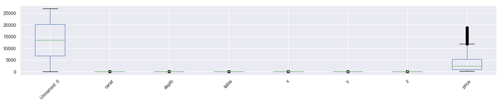

```python
df_num.boxplot(figsize=(20,3))
plt.xticks(rotation=45)
plt.show()
```

```python
from scipy.stats import zscore
df_num_scaled=df_num.apply(zscore)
df_num_scaled.head()
```

|  | Unnamed: 0 | carat | depth | table | x | y | z | price |
| --- | --- | --- | --- | --- | --- | --- | --- | --- |
| 0 | -1.731904 | -1.043125 | 0.253399 | 0.244112 | -1.295920 | -1.240065 | -1.224865 | -0.854851 |
| 1 | -1.731776 | -0.980310 | -0.679158 | 0.244112 | -1.162787 | -1.094057 | -1.169142 | -0.734303 |
| 2 | -1.731647 | 0.213173 | 0.325134 | 1.140496 | 0.275049 | 0.331668 | 0.335404 | 0.584271 |
| 3 | -1.731519 | -0.791865 | -0.105277 | -0.652273 | -0.807766 | -0.802041 | -0.806936 | -0.709945 |
| 4 | -1.731390 | -1.022187 | -0.966099 | 0.692304 | -1.224916 | -1.119823 | -1.238796 | -0.785257 |

```python
def treat_outlier(col):
    sorted(col)
    Q1,Q3=np.percentile(col,[25,75])
    IQR=Q3-Q1
    lower_range= Q1-(1.5 * IQR)
    upper_range= Q3+(1.5 * IQR)
    print(upper_range)
    return lower_range, upper_range
```

```python
for feature in df_num.columns:
    lr,ur=treat_outlier(df_num_scaled[feature])
    df_num_scaled[feature]=np.where(df_num_scaled[feature]>ur,ur,df_num_scaled[feature])
    df_num_scaled[feature]=np.where(df_num_scaled[feature]<lr,lr,df_num_scaled[feature])
```

```
3.4639535229852165
2.568732749976065
2.0467771475943333
2.7091685539239156
3.177346386472734
3.0467725621447035
3.079807913169288
1.9981653077789507
```

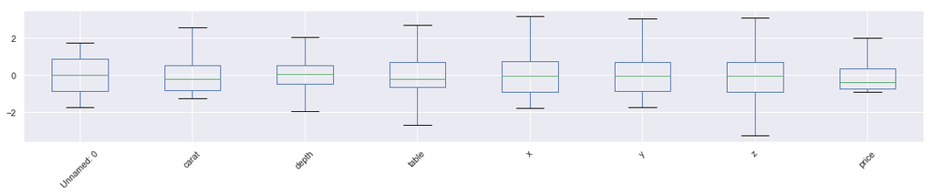

```python
df_num_scaled.boxplot(figsize=(20,3))
plt.xticks(rotation=45)
plt.show()
```

```python
new_df_scaled = pd.concat([df_cat, df_num_scaled], axis=1)
new_df_scaled.head()
```

|  | cut | color | clarity | Unnamed: 0 | carat | depth | table | x | y | z | price |
| --- | --- | --- | --- | --- | --- | --- | --- | --- | --- | --- | --- |
| 0 | Ideal | E | SI1 | -1.731904 | -1.043125 | 0.253399 | 0.244112 | -1.295920 | -1.240065 | -1.224865 | -0.854851 |
| 1 | Premium | G | IF | -1.731776 | -0.980310 | -0.679158 | 0.244112 | -1.162787 | -1.094057 | -1.169142 | -0.734303 |
| 2 | Very Good | E | VVS2 | -1.731647 | 0.213173 | 0.325134 | 1.140496 | 0.275049 | 0.331668 | 0.335404 | 0.584271 |
| 3 | Ideal | F | VS1 | -1.731519 | -0.791865 | -0.105277 | -0.652273 | -0.807766 | -0.802041 | -0.806936 | -0.709945 |
| 4 | Ideal | F | VVS1 | -1.731390 | -1.022187 | -0.966099 | 0.692304 | -1.224916 | -1.119823 | -1.238796 | -0.785257 |

### 1.3 Encode the data (having string values) for Modelling. Data Split: Split the data into test and train (70:30). Apply Linear regression. Performance Metrics: Check the performance of Predictions on Train and Test sets using Rsquare, RMSE.

```python
df_encoded = pd.get_dummies(new_df_scaled, columns=['cut','color','clarity'],drop_first=True)
df_encoded.head()
```

|  | Unnamed: 0 | carat | depth | table | x | y | z | price | cut_Good | cut_Ideal | ... | color_H | color_I | color_J | clarity_IF | clarity_SI1 | clarity_SI2 | clarity_VS1 | clarity_VS2 | clarity_VVS1 | clarity_VVS2 |
| --- | --- | --- | --- | --- | --- | --- | --- | --- | --- | --- | --- | --- | --- | --- | --- | --- | --- | --- | --- | --- | --- |
| 0 | -1.731904 | -1.043125 | 0.253399 | 0.244112 | -1.295920 | -1.240065 | -1.224865 | -0.854851 | 0 | 1 | ... | 0 | 0 | 0 | 0 | 1 | 0 | 0 | 0 | 0 | 0 |
| 1 | -1.731776 | -0.980310 | -0.679158 | 0.244112 | -1.162787 | -1.094057 | -1.169142 | -0.734303 | 0 | 0 | ... | 0 | 0 | 0 | 1 | 0 | 0 | 0 | 0 | 0 | 0 |
| 2 | -1.731647 | 0.213173 | 0.325134 | 1.140496 | 0.275049 | 0.331668 | 0.335404 | 0.584271 | 0 | 0 | ... | 0 | 0 | 0 | 0 | 0 | 0 | 0 | 0 | 0 | 1 |
| 3 | -1.731519 | -0.791865 | -0.105277 | -0.652273 | -0.807766 | -0.802041 | -0.806936 | -0.709945 | 0 | 1 | ... | 0 | 0 | 0 | 0 | 0 | 0 | 1 | 0 | 0 | 0 |
| 4 | -1.731390 | -1.022187 | -0.966099 | 0.692304 | -1.224916 | -1.119823 | -1.238796 | -0.785257 | 0 | 1 | ... | 0 | 0 | 0 | 0 | 0 | 0 | 0 | 0 | 1 | 0 |

5 rows × 25 columns

```python
df_encoded.columns
```

```
Index(['Unnamed: 0', 'carat', 'depth', 'table', 'x', 'y', 'z', 'price',
       'cut_Good', 'cut_Ideal', 'cut_Premium', 'cut_Very Good', 'color_E',
       'color_F', 'color_G', 'color_H', 'color_I', 'color_J', 'clarity_IF',
       'clarity_SI1', 'clarity_SI2', 'clarity_VS1', 'clarity_VS2',
       'clarity_VVS1', 'clarity_VVS2'],
      dtype='object')
```

```python
df_encoded = df_encoded.drop(columns=['Unnamed: 0'], axis=1)
```

```python
X = df_encoded.drop('price', axis=1)

y = df_encoded[['price']]
X.head()
```

|  | carat | depth | table | x | y | z | cut_Good | cut_Ideal | cut_Premium | cut_Very Good | ... | color_H | color_I | color_J | clarity_IF | clarity_SI1 | clarity_SI2 | clarity_VS1 | clarity_VS2 | clarity_VVS1 | clarity_VVS2 |
| --- | --- | --- | --- | --- | --- | --- | --- | --- | --- | --- | --- | --- | --- | --- | --- | --- | --- | --- | --- | --- | --- |
| 0 | -1.043125 | 0.253399 | 0.244112 | -1.295920 | -1.240065 | -1.224865 | 0 | 1 | 0 | 0 | ... | 0 | 0 | 0 | 0 | 1 | 0 | 0 | 0 | 0 | 0 |
| 1 | -0.980310 | -0.679158 | 0.244112 | -1.162787 | -1.094057 | -1.169142 | 0 | 0 | 1 | 0 | ... | 0 | 0 | 0 | 1 | 0 | 0 | 0 | 0 | 0 | 0 |
| 2 | 0.213173 | 0.325134 | 1.140496 | 0.275049 | 0.331668 | 0.335404 | 0 | 0 | 0 | 1 | ... | 0 | 0 | 0 | 0 | 0 | 0 | 0 | 0 | 0 | 1 |
| 3 | -0.791865 | -0.105277 | -0.652273 | -0.807766 | -0.802041 | -0.806936 | 0 | 1 | 0 | 0 | ... | 0 | 0 | 0 | 0 | 0 | 0 | 1 | 0 | 0 | 0 |
| 4 | -1.022187 | -0.966099 | 0.692304 | -1.224916 | -1.119823 | -1.238796 | 0 | 1 | 0 | 0 | ... | 0 | 0 | 0 | 0 | 0 | 0 | 0 | 0 | 1 | 0 |

5 rows × 23 columns

```python
y.head()
```

|  | price |
| --- | --- |
| 0 | -0.854851 |
| 1 | -0.734303 |
| 2 | 0.584271 |
| 3 | -0.709945 |
| 4 | -0.785257 |

```python
X_train, X_test, y_train, y_test = train_test_split(X, y, test_size=0.3 , random_state=42)
```

### Linear Regression Model

```python
regression_model = LinearRegression()
regression_model.fit(X_train, y_train)
```

```
LinearRegression()
```

```python
for idx, col_name in enumerate(X_train.columns):
    print("The coefficient for {} is {}".format(col_name, regression_model.coef_[0][idx]))
```

```
The coefficient for carat is 1.081627832522888
The coefficient for depth is 0.012467768513946348
The coefficient for table is -0.010375104168364378
The coefficient for x is -0.28583158930894487
The coefficient for y is 0.3338652177635207
The coefficient for z is -0.17104194176343152
The coefficient for cut_Good is 0.08632175838808641
The coefficient for cut_Ideal is 0.14741709168972442
The coefficient for cut_Premium is 0.13708966355071203
The coefficient for cut_Very Good is 0.11958512818375423
The coefficient for color_E is -0.056527359921143654
The coefficient for color_F is -0.0696128596080928
The coefficient for color_G is -0.11639282676700596
The coefficient for color_H is -0.21601184437275148
The coefficient for color_I is -0.33268780880422083
The coefficient for color_J is -0.47964981363888193
The coefficient for clarity_IF is 1.014064310227127
The coefficient for clarity_SI1 is 0.6466590629622312
The coefficient for clarity_SI2 is 0.43938535770675996
The coefficient for clarity_VS1 is 0.8505783926251638
The coefficient for clarity_VS2 is 0.7780939346329789
The coefficient for clarity_VVS1 is 0.9446069412003394
The coefficient for clarity_VVS2 is 0.9476542157836995
```

```python
intercept = regression_model.intercept_[0]

print("The intercept for our model is {}".format(intercept))
```

```
The intercept for our model is -0.7523485007042121
```

```python
# R square on training data
print("R square value for training data ",regression_model.score(X_train, y_train))
```

```
R square value for training data  0.9404067032706919
```

```python
# R square on testing data
print("R square value for testing data ",regression_model.score(X_test, y_test))
```

```
R square value for testing data  0.9416664173652372
```

```python
#RMSE on Training data
predicted_train=regression_model.fit(X_train, y_train).predict(X_train)
print("Mean squared error for the training data is ",np.sqrt(metrics.mean_squared_error(y_train,predicted_train)))
```

```
Mean squared error for the training data is  0.20982119520296377
```

```python
#RMSE on Testing data
predicted_test=regression_model.fit(X_train, y_train).predict(X_test)
print("Mean squared error for the testing data is ",np.sqrt(metrics.mean_squared_error(y_test,predicted_test)))
```

```
Mean squared error for the testing data is  0.2098640889031238
```

```python
from statsmodels.stats.outliers_influence import variance_inflation_factor
```

```python
vif = [variance_inflation_factor(X.values, ix) for ix in range(X.shape[1])]
```

```python
i=0
for column in X.columns:
    if i < 11:
        print (column ,"--->",  vif[i])
        i = i+1
```

```
carat ---> 33.35086119845924
depth ---> 4.573918951598584
table ---> 1.772885281261897
x ---> 463.5542785436457
y ---> 462.769821646584
z ---> 238.65819968687333
cut_Good ---> 3.609618194943713
cut_Ideal ---> 14.34812508118844
cut_Premium ---> 8.623414379121153
cut_Very Good ---> 7.848451571723695
color_E ---> 2.371070464762613
```

### Ridge Regression Model

```python
from sklearn.linear_model import Ridge
```

```python
ridge = Ridge(alpha=.3)
ridge.fit(X_train,y_train)
print ("The coefficient for the Ridge model:", (ridge.coef_))
```

```
The coefficient for the Ridge model: [[ 1.08097395  0.01236059 -0.01041468 -0.28263441  0.33056432 -0.17055804
   0.08692936  0.14804495  0.13757653  0.1203011  -0.05636345 -0.06942944
  -0.11614727 -0.21578484 -0.33237215 -0.47917899  1.00672437  0.63986318
   0.43266118  0.84368165  0.7712573   0.93753083  0.9406768 ]]
```

```python
print("R square value for training data ",ridge.score(X_train, y_train))
print("R square value for testing data ",ridge.score(X_test, y_test))
```

```
R square value for training data  0.9404058025987212
R square value for testing data  0.9416568212139137
```

```python
print("The intercept for our model is {}".format(ridge.intercept_))
```

```
The intercept for our model is [-0.7463866]
```

```python
predicted_train=ridge.fit(X_train, y_train).predict(X_train)
print("Mean squared error for the training data is ",np.sqrt(metrics.mean_squared_error(y_train,predicted_train)))
```

```
Mean squared error for the training data is  0.2098227807785714
```

```python
predicted_test=ridge.fit(X_train, y_train).predict(X_test)
print("Mean squared error for the testing data is ",np.sqrt(metrics.mean_squared_error(y_test,predicted_test)))
```

```
Mean squared error for the testing data is  0.20988135001282085
```

### OLS Method

```python
df_encoded.columns
```

```
Index(['carat', 'depth', 'table', 'x', 'y', 'z', 'price', 'cut_Good',
       'cut_Ideal', 'cut_Premium', 'cut_Very Good', 'color_E', 'color_F',
       'color_G', 'color_H', 'color_I', 'color_J', 'clarity_IF', 'clarity_SI1',
       'clarity_SI2', 'clarity_VS1', 'clarity_VS2', 'clarity_VVS1',
       'clarity_VVS2'],
      dtype='object')
```

```python
df_encoded.rename(columns = {'cut_Very Good' : 'cut_Very_Good'}, inplace = True)
```

```python
import statsmodels.formula.api as smf
lm1 = smf.ols(formula= 'price ~ carat + depth + table + x+ y + z + cut_Good + cut_Ideal + cut_Premium + cut_Very_Good + color_E + color_F + color_G + color_H + color_I + color_J + clarity_IF + clarity_SI1 + clarity_SI2 + clarity_VS1 + clarity_VS2 + clarity_VVS1 + clarity_VVS2', data = df_encoded).fit()
print("The Coefficient are \n\n\n ",lm1.params)
```

```
The Coefficient are


  Intercept       -0.781720
carat            1.086958
depth            0.008694
table           -0.011344
x               -0.303284
y                0.318809
z               -0.142880
cut_Good         0.097282
cut_Ideal        0.156601
cut_Premium      0.151019
cut_Very_Good    0.129184
color_E         -0.049548
color_F         -0.063134
color_G         -0.104572
color_H         -0.210754
color_I         -0.328478
color_J         -0.472208
clarity_IF       1.016587
clarity_SI1      0.658588
clarity_SI2      0.454275
clarity_VS1      0.861128
clarity_VS2      0.789454
clarity_VVS1     0.966044
clarity_VVS2     0.960458
dtype: float64
```

```python
print(lm1.summary())  #Inferential statistics
```

```
                            OLS Regression Results
==============================================================================
Dep. Variable:                  price   R-squared:                       0.941
Model:                            OLS   Adj. R-squared:                  0.941
Method:                 Least Squares   F-statistic:                 1.862e+04
Date:                Sun, 19 Dec 2021   Prob (F-statistic):               0.00
Time:                        21:09:25   Log-Likelihood:                 3852.4
No. Observations:               26958   AIC:                            -7657.
Df Residuals:                   26934   BIC:                            -7460.
Df Model:                          23
Covariance Type:            nonrobust
=================================================================================
                    coef    std err          t      P>|t|      [0.025      0.975]
---------------------------------------------------------------------------------
Intercept        -0.7817      0.014    -57.768      0.000      -0.808      -0.755
carat             1.0870      0.008    142.536      0.000       1.072       1.102
depth             0.0087      0.003      2.780      0.005       0.003       0.015
table            -0.0113      0.002     -6.383      0.000      -0.015      -0.008
x                -0.3033      0.028    -10.961      0.000      -0.358      -0.249
y                 0.3188      0.029     10.986      0.000       0.262       0.376
z                -0.1429      0.020     -6.980      0.000      -0.183      -0.103
cut_Good          0.0973      0.009     10.785      0.000       0.080       0.115
cut_Ideal         0.1566      0.009     17.821      0.000       0.139       0.174
cut_Premium       0.1510      0.008     17.909      0.000       0.134       0.168
cut_Very_Good     0.1292      0.009     14.981      0.000       0.112       0.146
color_E          -0.0495      0.005    -10.511      0.000      -0.059      -0.040
color_F          -0.0631      0.005    -13.219      0.000      -0.072      -0.054
color_G          -0.1046      0.005    -22.417      0.000      -0.114      -0.095
color_H          -0.2108      0.005    -42.348      0.000      -0.221      -0.201
color_I          -0.3285      0.006    -59.270      0.000      -0.339      -0.318
color_J          -0.4722      0.007    -69.454      0.000      -0.486      -0.459
clarity_IF        1.0166      0.013     75.358      0.000       0.990       1.043
clarity_SI1       0.6586      0.012     57.163      0.000       0.636       0.681
clarity_SI2       0.4543      0.012     39.232      0.000       0.432       0.477
clarity_VS1       0.8611      0.012     73.230      0.000       0.838       0.884
clarity_VS2       0.7895      0.012     68.162      0.000       0.767       0.812
clarity_VVS1      0.9660      0.012     77.536      0.000       0.942       0.990
clarity_VVS2      0.9605      0.012     79.250      0.000       0.937       0.984
==============================================================================
Omnibus:                     6631.652   Durbin-Watson:                   2.006
Prob(Omnibus):                  0.000   Jarque-Bera (JB):            25175.638
Skew:                           1.191   Prob(JB):                         0.00
Kurtosis:                       7.091   Cond. No.                         58.0
==============================================================================

Warnings:
[1] Standard Errors assume that the covariance matrix of the errors is correctly specified.
```

```python
# Let us check the sum of squared errors by predicting value of y for test cases and
# subtracting from the actual y for the test cases

mse = np.mean((regression_model.predict(X_test)-y_test)**2)

# underroot of mean_sq_error is standard deviation i.e. avg variance between predicted and actual

import math

print("Mean squared error for the testing data is ",math.sqrt(mse))
```

```
Mean squared error for the testing data is  0.20986408890312383
```

```python
# predict mileage (mpg) for a set of attributes not in the training or test set
y_pred = regression_model.predict(X_test)
```

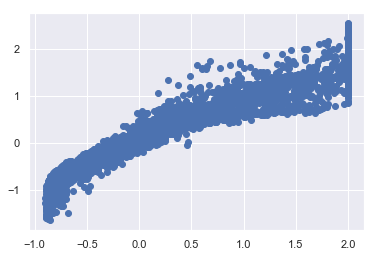

```python
plt.scatter(y_test['price'], y_pred)
```

```python
print("price =")
for i,j in np.array(lm1.params.reset_index()):
    print(' ({}) * {} +'.format(round(j,2),i),end=' ')
```

[output not shown]

### 1.4 Inference: Basis on these predictions, what are the business insights and recommendations.

Based on the R2(R squared) value, The company making out the better profitable share by distinguishing the higher profitable stones and lower profitable stones so that the company can increase the price for higher and lower profitable stones to make higher profits.

The best 5 attributes that are most important from the coefficients are carat, clarity_IF, clarity_VVS2, clarity_VVS1, clarity_VS1. These are the best attributes that will increase the price of the diamond costliest.

$Business Insights:$

$Train set:$

rsquare: 0.94

adjusted square: 0.94

R - Square is 0.94 which tells the correlation between price of diamonds vs. different independent variable’s explained by 94%

If we see the final model:

price = (-0.78) *Intercept + (1.09)* carat + (0.01) *depth + (-0.01)* table + (-0.3) *x + (0.32)* y + (-0.14) *z + (0.1)* cut_Good + (0.16) *cut_Ideal + (0.15)* cut_Premium + (0.13) *cut_Very_Good + (-0.05)* color_E + (-0.06) *color_F + (-0.1)* color_G + (-0.21) *color_H + (-0.33)* color_I + (-0.47) *color_J + (1.02)* clarity_IF + (0.66) *clarity_SI1 + (0.45)* clarity_SI2 + (0.86) *clarity_VS1 + (0.79)* clarity_VS2 + (0.97) *clarity_VVS1 + (0.96)* clarity_VVS2

Co-efficient of the Carat is highest most, which signifies if there is increase of one unit of carat there will increase of 1.09 in price.

Next most positive effecting indepenedent variable is IF clarity type variable.

Most Negatively effecting parameter is J color type diamonds ,means a loss of -0.47 will occur with decrease the price of one unit of J color type diamonds.

$Test set:$

rsquare: 0.941

Adjusted square: 0.941

Finally, Our linear model is good as the r-square difference in train & test dataset is less than 5%.

$Recommendations :$

To Increase the price of the diamond, carat,clarity of the diamond needs to be increased so that the price of the diamond increase which inturn increases profits. The company can sell the diamonds and make higher profitable price from the stone with lower profitable price.

### Problem 2: Logistic Regression and LDA

You are hired by a tour and travel agency which deals in selling holiday packages. You are provided details of 872 employees of a company. Among these employees, some opted for the package and some didn't. You have to help the company in predicting whether an employee will opt for the package or not on the basis of the information given in the data set. Also, find out the important factors on the basis of which the company will focus on particular employees to sell their packages.

### 2.1 Data Ingestion: Read the dataset. Do the descriptive statistics and do null value condition check, write an inference on it. Perform Univariate and Bivariate Analysis. Do exploratory data analysis.

```python
df = pd.read_csv("Holiday_Package.csv")
df.head()
```

|  | Unnamed: 0 | Holliday_Package | Salary | age | educ | no_young_children | no_older_children | foreign |
| --- | --- | --- | --- | --- | --- | --- | --- | --- |
| 0 | 1 | no | 48412 | 30 | 8 | 1 | 1 | no |
| 1 | 2 | yes | 37207 | 45 | 8 | 0 | 1 | no |
| 2 | 3 | no | 58022 | 46 | 9 | 0 | 0 | no |
| 3 | 4 | no | 66503 | 31 | 11 | 2 | 0 | no |
| 4 | 5 | no | 66734 | 44 | 12 | 0 | 2 | no |

```python
df.shape
```

```
(872, 8)
```

```python
df.info()
```

```
<class 'pandas.core.frame.DataFrame'>
RangeIndex: 872 entries, 0 to 871
Data columns (total 8 columns):
Unnamed: 0           872 non-null int64
Holliday_Package     872 non-null object
Salary               872 non-null int64
age                  872 non-null int64
educ                 872 non-null int64
no_young_children    872 non-null int64
no_older_children    872 non-null int64
foreign              872 non-null object
dtypes: int64(6), object(2)
memory usage: 54.6+ KB
```

```python
df.describe()
```

|  | Unnamed: 0 | Salary | age | educ | no_young_children | no_older_children |
| --- | --- | --- | --- | --- | --- | --- |
| count | 872.000000 | 872.000000 | 872.000000 | 872.000000 | 872.000000 | 872.000000 |
| mean | 436.500000 | 47729.172018 | 39.955275 | 9.307339 | 0.311927 | 0.982798 |
| std | 251.869014 | 23418.668531 | 10.551675 | 3.036259 | 0.612870 | 1.086786 |
| min | 1.000000 | 1322.000000 | 20.000000 | 1.000000 | 0.000000 | 0.000000 |
| 25% | 218.750000 | 35324.000000 | 32.000000 | 8.000000 | 0.000000 | 0.000000 |
| 50% | 436.500000 | 41903.500000 | 39.000000 | 9.000000 | 0.000000 | 1.000000 |
| 75% | 654.250000 | 53469.500000 | 48.000000 | 12.000000 | 0.000000 | 2.000000 |
| max | 872.000000 | 236961.000000 | 62.000000 | 21.000000 | 3.000000 | 6.000000 |

```python
df.dtypes
```

```
Unnamed: 0            int64
Holliday_Package     object
Salary                int64
age                   int64
educ                  int64
no_young_children     int64
no_older_children     int64
foreign              object
dtype: object
```

```python
df.isnull().sum()
```

```
Unnamed: 0           0
Holliday_Package     0
Salary               0
age                  0
educ                 0
no_young_children    0
no_older_children    0
foreign              0
dtype: int64
```

```python
dups = df.duplicated()
print('Number of duplicate rows = %d' % (dups.sum()))
```

```
Number of duplicate rows = 0
```

```python
for column in df.columns:
    if df[column].dtype == 'object':
        print(column.upper(),': ',df[column].nunique())
        print(df[column].value_counts().sort_values())
        print('\n')
```

```
HOLLIDAY_PACKAGE :  2
yes    401
no     471
Name: Holliday_Package, dtype: int64


FOREIGN :  2
yes    216
no     656
Name: foreign, dtype: int64
```

### Univariate Analysis

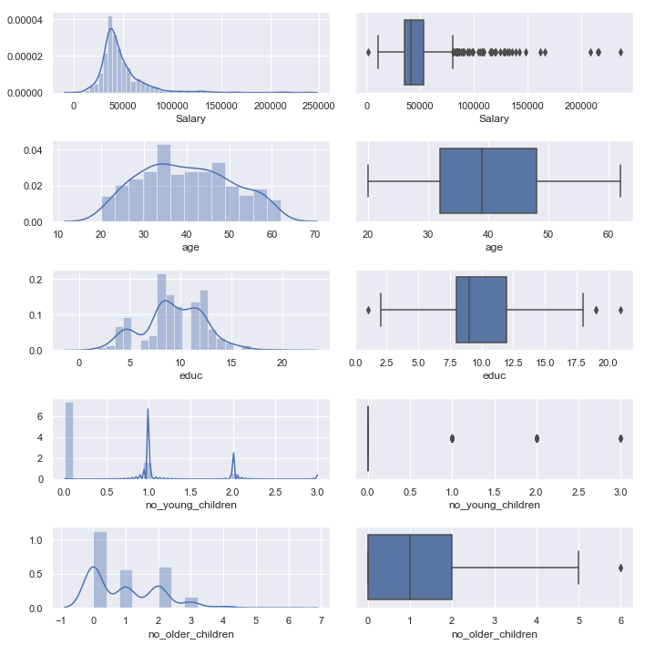

```python
fig, axes = plt.subplots(nrows=5,ncols=2)
fig.set_size_inches(10,10)
sns.distplot(df['Salary'], kde=True, ax=axes[0][0])
sns.boxplot(x='Salary', data=df, ax=axes[0][1])
sns.distplot(df['age'] , kde=True, ax=axes[1][0])
sns.boxplot(x='age', data=df , ax=axes[1][1])
sns.distplot(df['educ'] , kde=True, ax=axes[2][0])
sns.boxplot(x='educ', data=df , ax=axes[2][1])
sns.distplot(df['no_young_children'], kde=True, ax=axes[3][0])
sns.boxplot(x='no_young_children', data=df, ax=axes[3][1])
sns.distplot(df['no_older_children'] , kde=True, ax=axes[4][0])
sns.boxplot(x='no_older_children', data=df , ax=axes[4][1])
plt.tight_layout()
plt.show()
```

```
no     471
yes    401
Name: Holliday_Package, dtype: int64
```

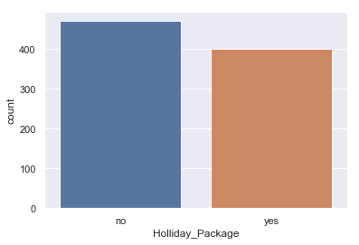

```python
sns.countplot(df["Holliday_Package"])
df["Holliday_Package"].value_counts()
```

```
no     656
yes    216
Name: foreign, dtype: int64
```

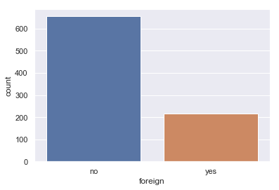

```python
sns.countplot(df["foreign"])
df["foreign"].value_counts()
```

### Bi-Variate Analysis

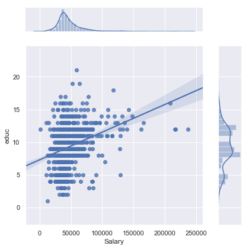

```python
sns.set(style="darkgrid", color_codes=True)
sns.jointplot(df["Salary"],df["educ"],kind="reg")
plt.tight_layout()
plt.show()
```

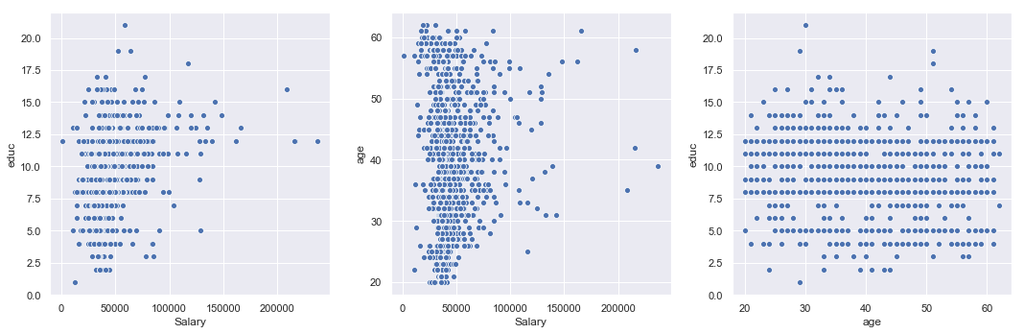

```python
fig, axes = plt.subplots(nrows=1,ncols=3)
fig.set_size_inches(15,5)
# plt.figure(figsize=(12,7))
sns.scatterplot(df['Salary'], df['educ'], ax=axes[0])
sns.scatterplot(df['Salary'], df['age'], ax=axes[1])
sns.scatterplot(df['age'], df['educ'], ax=axes[2])
plt.tight_layout()
plt.show()
```

### Multivariate Analysis

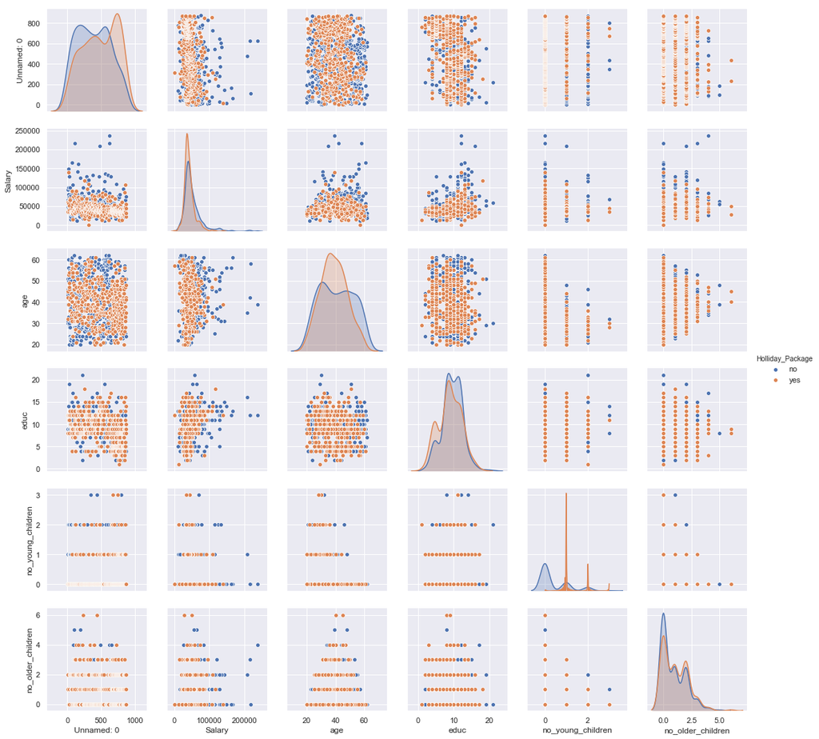

```python
sns.pairplot(df,hue="Holliday_Package")
plt.show()
```

```python
df.corr()
```

|  | Unnamed: 0 | Salary | age | educ | no_young_children | no_older_children |
| --- | --- | --- | --- | --- | --- | --- |
| Unnamed: 0 | 1.000000 | -0.193249 | -0.103782 | -0.296015 | 0.052146 | -0.025852 |
| Salary | -0.193249 | 1.000000 | 0.071709 | 0.326540 | -0.029664 | 0.113772 |
| age | -0.103782 | 0.071709 | 1.000000 | -0.149294 | -0.519093 | -0.116205 |
| educ | -0.296015 | 0.326540 | -0.149294 | 1.000000 | 0.098350 | -0.036321 |
| no_young_children | 0.052146 | -0.029664 | -0.519093 | 0.098350 | 1.000000 | -0.238428 |
| no_older_children | -0.025852 | 0.113772 | -0.116205 | -0.036321 | -0.238428 | 1.000000 |

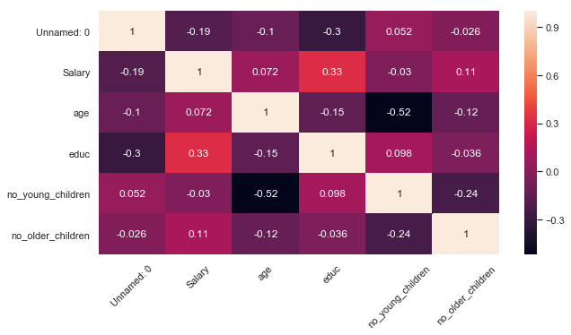

```python
plt.figure(figsize=(10,5))
plt.xticks(rotation=45)
sns.heatmap(df.corr(),annot=True)
plt.show()
```

```python
df_cat = df.select_dtypes(include = ['object'])
df_num = df.select_dtypes(include = ['float64','int64'])
```

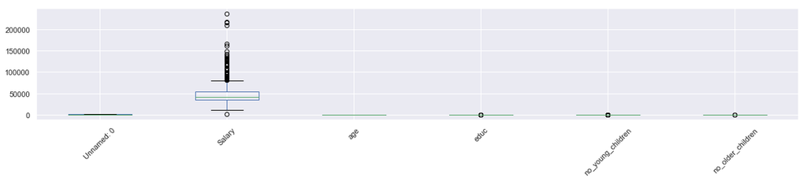

```python
df_num.boxplot(figsize=(20,3))
plt.xticks(rotation=45)
plt.show()
```

```python
def treat_outlier(col):
    sorted(col)
    Q1,Q3=np.percentile(col,[25,75])
    IQR=Q3-Q1
    lower_range= Q1-(1.5 * IQR)
    upper_range= Q3+(1.5 * IQR)
    return lower_range, upper_range
```

```python
for feature in df_num.columns:
    lr,ur=treat_outlier(df_num[feature])
    df_num[feature]=np.where(df_num[feature]>ur,ur,df_num[feature])
    df_num[feature]=np.where(df_num[feature]<lr,lr,df_num[feature])
```

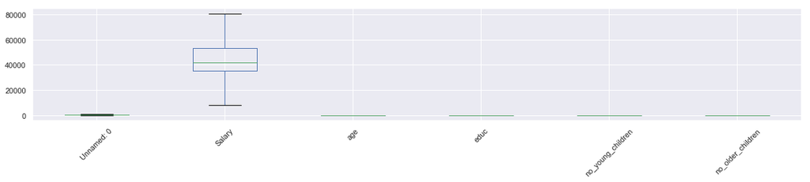

```python
df_num.boxplot(figsize=(20,3))
plt.xticks(rotation=45)
plt.show()
```

```python
df = pd.concat([df_cat, df_num], axis=1)
```

```python
df = df.drop(columns=['Unnamed: 0'], axis=1)
```

```python
df.head()
```

|  | Holliday_Package | foreign | Salary | age | educ | no_young_children | no_older_children |
| --- | --- | --- | --- | --- | --- | --- | --- |
| 0 | no | no | 48412.0 | 30.0 | 8.0 | 0.0 | 1.0 |
| 1 | yes | no | 37207.0 | 45.0 | 8.0 | 0.0 | 1.0 |
| 2 | no | no | 58022.0 | 46.0 | 9.0 | 0.0 | 0.0 |
| 3 | no | no | 66503.0 | 31.0 | 11.0 | 0.0 | 0.0 |
| 4 | no | no | 66734.0 | 44.0 | 12.0 | 0.0 | 2.0 |

### 2.2 Do not scale the data. Encode the data (having string values) for Modelling. Data Split: Split the data into train and test (70:30). Apply Logistic Regression and LDA (linear discriminant analysis).

```python
data = pd.get_dummies(df, columns=['Holliday_Package','foreign'], drop_first = True)
data.head()
```

|  | Salary | age | educ | no_young_children | no_older_children | Holliday_Package_yes | foreign_yes |
| --- | --- | --- | --- | --- | --- | --- | --- |
| 0 | 48412.0 | 30.0 | 8.0 | 0.0 | 1.0 | 0 | 0 |
| 1 | 37207.0 | 45.0 | 8.0 | 0.0 | 1.0 | 1 | 0 |
| 2 | 58022.0 | 46.0 | 9.0 | 0.0 | 0.0 | 0 | 0 |
| 3 | 66503.0 | 31.0 | 11.0 | 0.0 | 0.0 | 0 | 0 |
| 4 | 66734.0 | 44.0 | 12.0 | 0.0 | 2.0 | 0 | 0 |

```python
X = data.drop('Holliday_Package_yes', axis=1)

y = data['Holliday_Package_yes']
```

```python
X_train, X_test, y_train, y_test = train_test_split(X, y, test_size=0.30 , random_state=42,stratify=y)
X_train.shape
```

```
(610, 6)
```

```python
X_train.head()
```

|  | Salary | age | educ | no_young_children | no_older_children | foreign_yes |
| --- | --- | --- | --- | --- | --- | --- |
| 400 | 59692.00 | 43.0 | 11.0 | 0.0 | 2.0 | 0 |
| 234 | 22366.00 | 55.0 | 7.0 | 0.0 | 2.0 | 0 |
| 338 | 41582.00 | 36.0 | 9.0 | 0.0 | 3.0 | 0 |
| 71 | 35344.00 | 35.0 | 9.0 | 0.0 | 2.0 | 0 |
| 727 | 80687.75 | 55.0 | 15.0 | 0.0 | 0.0 | 1 |

```python
X_train_LDA, X_test_LDA, y_train_LDA, y_test_LDA = train_test_split(X, y, test_size=0.30 , random_state=42)
X_train_LDA.shape
```

```
(610, 6)
```

### 2.3 Performance Metrics: Check the performance of Predictions on Train and Test sets using Accuracy, Confusion Matrix, Plot ROC curve and get ROC_AUC score for each model Final Model: Compare Both the models and write inference which model is best/optimized.

### $ Logistic Regression $

```python
grid={'penalty':['l1','l2','none'],
      'solver':['lbfgs', 'liblinear'],
      'tol':[0.0001,0.000001]}
```

```python
from sklearn.linear_model import LogisticRegression
model = LogisticRegression(max_iter=100000,n_jobs=2)
```

```python
grid_search = GridSearchCV(estimator = model, param_grid = grid, cv = 3,n_jobs=-1,scoring='f1')
```

```python
grid_search.fit(X_train, y_train)
```

```
GridSearchCV(cv=3, estimator=LogisticRegression(max_iter=100000, n_jobs=2),
             n_jobs=-1,
             param_grid={'penalty': ['l1', 'l2', 'none'],
                         'solver': ['lbfgs', 'liblinear'],
                         'tol': [0.0001, 1e-06]},
             scoring='f1')
```

```python
grid_search.best_params_
```

```
{'penalty': 'l2', 'solver': 'liblinear', 'tol': 1e-06}
```

```python
best_model = grid_search.best_estimator_
best_model
```

```
LogisticRegression(max_iter=100000, n_jobs=2, solver='liblinear', tol=1e-06)
```

```python
# Prediction on the training set

ytrain_predict = best_model.predict(X_train)
ytest_predict = best_model.predict(X_test)
ytrain_predict
```

```
array([0, 1, 0, 0, 0, 0, 0, 1, 1, 0, 0, 0, 0, 0, 0, 0, 0, 0, 0, 0, 1, 0,
       0, 0, 0, 0, 1, 0, 0, 0, 0, 1, 0, 0, 1, 0, 0, 1, 0, 0, 0, 1, 0, 0,
       0, 0, 0, 1, 0, 1, 1, 0, 0, 0, 1, 0, 0, 1, 1, 0, 0, 1, 0, 0, 0, 0,
       0, 1, 0, 0, 0, 0, 0, 0, 1, 1, 0, 0, 0, 0, 1, 0, 1, 0, 0, 0, 1, 0,
       0, 0, 1, 0, 0, 0, 1, 0, 1, 0, 0, 1, 0, 0, 0, 1, 0, 0, 1, 1, 1, 0,
       0, 1, 0, 0, 0, 1, 0, 0, 1, 0, 0, 0, 0, 0, 0, 1, 0, 0, 0, 0, 0, 0,
       0, 0, 1, 0, 0, 0, 1, 0, 0, 1, 0, 1, 1, 0, 0, 1, 0, 0, 1, 1, 0, 0,
       1, 1, 0, 0, 0, 1, 0, 0, 1, 0, 0, 0, 1, 0, 0, 1, 0, 0, 1, 0, 1, 1,
       0, 0, 1, 0, 0, 0, 0, 1, 0, 1, 0, 0, 1, 0, 0, 0, 0, 0, 0, 0, 1, 0,
       0, 0, 1, 0, 0, 0, 1, 0, 0, 0, 0, 1, 0, 0, 0, 0, 1, 0, 0, 0, 0, 0,
       0, 1, 0, 0, 0, 0, 0, 0, 0, 0, 1, 0, 1, 1, 0, 1, 0, 0, 0, 0, 1, 0,
       0, 0, 0, 0, 0, 1, 0, 0, 1, 0, 0, 0, 0, 0, 1, 1, 0, 0, 0, 1, 0, 0,
       0, 0, 0, 0, 0, 0, 0, 1, 1, 1, 0, 0, 0, 0, 0, 0, 0, 1, 0, 1, 0, 0,
       0, 0, 0, 0, 0, 0, 0, 1, 1, 0, 0, 1, 0, 1, 0, 0, 0, 0, 0, 0, 0, 0,
       0, 0, 0, 0, 0, 0, 0, 0, 0, 0, 0, 0, 0, 1, 1, 0, 0, 0, 1, 0, 1, 0,
       0, 1, 1, 0, 0, 0, 0, 0, 0, 1, 0, 0, 0, 0, 0, 1, 0, 1, 0, 0, 1, 0,
       0, 0, 1, 1, 0, 0, 0, 0, 1, 0, 0, 0, 1, 1, 0, 0, 0, 1, 1, 0, 1, 1,
       1, 1, 0, 0, 0, 0, 0, 0, 0, 0, 1, 0, 1, 1, 0, 0, 0, 1, 0, 0, 1, 0,
       0, 0, 1, 0, 1, 1, 0, 0, 0, 0, 0, 0, 1, 0, 0, 1, 0, 0, 1, 1, 0, 0,
       0, 0, 1, 0, 0, 0, 0, 1, 0, 0, 0, 0, 0, 0, 0, 0, 0, 1, 1, 0, 0, 1,
       0, 0, 1, 0, 1, 0, 1, 0, 0, 1, 0, 1, 1, 0, 0, 0, 0, 0, 0, 1, 0, 0,
       1, 0, 0, 0, 0, 0, 0, 0, 0, 0, 0, 1, 1, 0, 0, 0, 0, 1, 0, 0, 1, 0,
       1, 1, 1, 1, 0, 0, 0, 0, 0, 1, 1, 0, 1, 1, 0, 0, 1, 0, 1, 0, 0, 0,
       0, 1, 0, 0, 1, 0, 0, 0, 0, 0, 0, 0, 1, 1, 0, 0, 0, 0, 0, 0, 0, 0,
       0, 0, 1, 1, 0, 0, 0, 1, 1, 0, 1, 0, 0, 0, 0, 0, 0, 0, 0, 1, 0, 1,
       0, 0, 0, 1, 0, 0, 0, 1, 0, 0, 0, 0, 0, 1, 1, 0, 0, 0, 0, 1, 0, 0,
       0, 0, 1, 0, 1, 0, 0, 0, 0, 1, 0, 0, 1, 0, 0, 0, 1, 0, 1, 1, 1, 1,
       0, 0, 0, 0, 0, 0, 0, 0, 1, 1, 0, 0, 0, 0, 1, 0], dtype=uint8)
```

```python
## Getting the probabilities on the test set
ytest_predict_prob=best_model.predict_proba(X_test)
pd.DataFrame(ytest_predict_prob).head()
```

|  | 0 | 1 |
| --- | --- | --- |
| 0 | 0.378879 | 0.621121 |
| 1 | 0.541181 | 0.458819 |
| 2 | 0.603203 | 0.396797 |
| 3 | 0.598986 | 0.401014 |
| 4 | 0.448885 | 0.551115 |

```python
confusion_matrix(y_train,ytrain_predict)
```

```
array([[274,  55],
       [168, 113]], dtype=int64)
```

```python
## Confusion matrix on the training data

print(classification_report(y_train, ytrain_predict),'\n');
```

```
              precision    recall  f1-score   support

           0       0.62      0.83      0.71       329
           1       0.67      0.40      0.50       281

    accuracy                           0.63       610
   macro avg       0.65      0.62      0.61       610
weighted avg       0.64      0.63      0.62       610
```

```python
## Confusion matrix on the test data
confusion_matrix(y_test, ytest_predict)
```

```
array([[117,  25],
       [ 73,  47]], dtype=int64)
```

```python
## Confusion matrix on the test data

print(classification_report(y_test, ytest_predict),'\n');
```

```
              precision    recall  f1-score   support

           0       0.62      0.82      0.70       142
           1       0.65      0.39      0.49       120

    accuracy                           0.63       262
   macro avg       0.63      0.61      0.60       262
weighted avg       0.63      0.63      0.61       262
```

```
AUC: 0.661
```

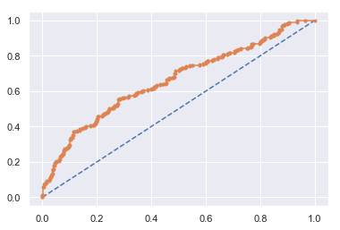

```python
# predict probabilities
probs = best_model.predict_proba(X_train)
# keep probabilities for the positive outcome only
probs = probs[:, 1]
# calculate AUC
from sklearn.metrics import roc_auc_score
lr_train_auc = roc_auc_score(y_train, probs)
print('AUC: %.3f' % lr_train_auc)
# calculate roc curve
from sklearn.metrics import roc_curve
fpr, tpr, thresholds = roc_curve(y_train, probs)
plt.plot([0, 1], [0, 1], linestyle='--')
# plot the roc curve for the model
plt.plot(fpr, tpr, marker='.')
# show the plot
plt.show()
```

```
AUC: 0.672
```

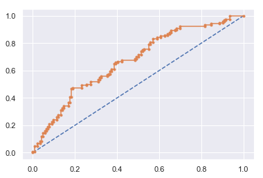

```python
# AUC and ROC for the test data


# predict probabilities
probs = best_model.predict_proba(X_test)
# keep probabilities for the positive outcome only
probs = probs[:, 1]
# calculate AUC
from sklearn.metrics import roc_auc_score
lr_test_auc = roc_auc_score(y_test, probs)
print('AUC: %.3f' % lr_test_auc)
# calculate roc curve
from sklearn.metrics import roc_curve
fpr, tpr, thresholds = roc_curve(y_test, probs)
plt.plot([0, 1], [0, 1], linestyle='--')
# plot the roc curve for the model
plt.plot(fpr, tpr, marker='.')
# show the plot
plt.show()
```

```python
lr_metrics=classification_report(y_train, ytrain_predict,output_dict=True)
dftr=pd.DataFrame(lr_metrics).transpose()
lr_train_f1=round(dftr.loc["1"][2],2)
lr_train_recall=round(dftr.loc["1"][1],2)
lr_train_precision=round(dftr.loc["1"][0],2)
lr_train_acc=round(dftr.loc["accuracy"][0],2)

print ('lr_train_precision ',lr_train_precision)
print ('lr_train_recall ',lr_train_recall)
print ('lr_train_f1 ',lr_train_f1)
print ('lr_train_acc ',lr_train_acc)
```

[output not shown]

```python
lr_metrics=classification_report(y_test, ytest_predict,output_dict=True)
dft=pd.DataFrame(lr_metrics).transpose()
lr_test_f1=round(dft.loc["1"][2],2)
lr_test_recall=round(dft.loc["1"][1],2)
lr_test_precision=round(dft.loc["1"][0],2)
lr_test_acc=round(dft.loc["accuracy"][0],2)
print ('lr_test_precision ',lr_test_precision)
print ('lr_test_recall ',lr_test_recall)
print ('lr_test_f1 ',lr_test_f1)
print ('lr_test_acc',lr_test_acc)
```

[output not shown]

### $LDA$

```python
clf = LinearDiscriminantAnalysis()
model=clf.fit(X_train_LDA,y_train_LDA)
model
```

```
LinearDiscriminantAnalysis()
```

```python
# Predict it
pred_class_train = model.predict(X_train_LDA)
pred_class_train
```

```
array([0, 1, 0, 0, 0, 1, 0, 0, 0, 1, 0, 0, 0, 0, 0, 0, 0, 0, 0, 0, 1, 0,
       0, 0, 0, 0, 0, 1, 0, 1, 1, 1, 0, 0, 0, 1, 0, 0, 1, 1, 0, 0, 0, 1,
       0, 1, 1, 0, 0, 0, 1, 0, 1, 0, 0, 1, 0, 1, 0, 0, 1, 1, 0, 0, 0, 1,
       0, 0, 0, 1, 0, 1, 0, 0, 0, 0, 0, 0, 0, 1, 1, 0, 0, 0, 1, 0, 0, 0,
       1, 0, 0, 0, 1, 1, 0, 0, 0, 0, 0, 0, 0, 0, 0, 1, 0, 1, 0, 0, 0, 1,
       0, 0, 1, 0, 0, 0, 0, 1, 0, 0, 0, 0, 0, 0, 1, 0, 1, 0, 0, 1, 0, 0,
       0, 0, 0, 0, 0, 1, 1, 0, 0, 1, 0, 0, 0, 1, 0, 0, 0, 0, 0, 1, 1, 0,
       0, 0, 0, 0, 0, 0, 0, 0, 0, 0, 0, 0, 1, 0, 0, 1, 0, 0, 0, 1, 0, 1,
       0, 0, 0, 0, 1, 0, 0, 0, 1, 0, 1, 0, 0, 0, 0, 0, 1, 1, 0, 0, 0, 1,
       0, 0, 1, 0, 0, 0, 0, 1, 0, 0, 0, 1, 0, 0, 1, 1, 0, 1, 0, 1, 1, 0,
       0, 0, 1, 0, 1, 1, 0, 1, 1, 0, 0, 0, 0, 0, 1, 1, 1, 0, 1, 0, 0, 0,
       0, 0, 0, 0, 0, 0, 0, 0, 1, 1, 0, 0, 0, 0, 1, 1, 0, 1, 1, 0, 0, 0,
       0, 0, 0, 0, 1, 1, 0, 0, 0, 0, 0, 1, 0, 0, 0, 0, 0, 1, 0, 1, 0, 0,
       0, 0, 0, 0, 1, 1, 0, 0, 0, 0, 1, 0, 0, 1, 0, 1, 0, 0, 0, 1, 0, 1,
       1, 1, 1, 0, 1, 1, 0, 1, 1, 1, 0, 0, 0, 0, 0, 1, 0, 0, 0, 0, 0, 0,
       0, 0, 0, 0, 0, 1, 0, 1, 1, 0, 1, 0, 0, 0, 0, 1, 1, 0, 1, 0, 0, 0,
       0, 0, 1, 1, 0, 0, 0, 0, 0, 1, 1, 0, 0, 0, 0, 0, 1, 0, 0, 1, 0, 0,
       0, 0, 0, 0, 1, 0, 0, 0, 0, 1, 0, 0, 1, 1, 0, 1, 0, 0, 1, 1, 1, 0,
       1, 1, 0, 1, 1, 0, 1, 0, 0, 0, 0, 1, 0, 0, 1, 0, 1, 0, 1, 1, 1, 0,
       0, 0, 0, 0, 0, 0, 0, 1, 1, 0, 0, 1, 1, 1, 1, 1, 0, 1, 0, 1, 0, 1,
       0, 0, 0, 1, 0, 0, 0, 0, 0, 1, 1, 1, 1, 0, 0, 0, 0, 1, 0, 0, 0, 0,
       0, 0, 1, 0, 0, 0, 1, 0, 0, 1, 1, 0, 1, 0, 0, 0, 0, 0, 0, 1, 0, 1,
       0, 0, 0, 0, 0, 1, 0, 0, 0, 0, 0, 0, 0, 0, 1, 0, 0, 0, 0, 0, 0, 0,
       0, 1, 0, 0, 0, 1, 1, 1, 0, 1, 0, 1, 0, 0, 1, 0, 0, 0, 0, 1, 0, 1,
       0, 1, 0, 0, 0, 0, 1, 0, 1, 0, 0, 1, 0, 0, 1, 0, 0, 0, 0, 0, 1, 0,
       0, 0, 0, 0, 0, 0, 1, 0, 1, 0, 1, 0, 0, 0, 0, 1, 0, 1, 1, 0, 1, 0,
       0, 1, 0, 1, 0, 0, 0, 0, 0, 0, 0, 0, 1, 0, 1, 0, 1, 0, 1, 0, 1, 0,
       0, 1, 0, 0, 0, 0, 0, 0, 0, 1, 0, 0, 0, 1, 1, 0], dtype=uint8)
```

```python
pred_class_test = model.predict(X_test_LDA)
```

```python
pred_prob_train = model.predict_proba(X_train_LDA)

# Test Data Probability Prediction
pred_prob_test = model.predict_proba(X_test_LDA)
```

```python
model.score(X_train_LDA,y_train_LDA)
```

```
0.6426229508196721
```

```python
print(classification_report(y_train_LDA, pred_class_train))
```

```
              precision    recall  f1-score   support

           0       0.63      0.81      0.71       331
           1       0.66      0.44      0.53       279

    accuracy                           0.64       610
   macro avg       0.65      0.63      0.62       610
weighted avg       0.65      0.64      0.63       610
```

```python
confusion_matrix(y_train_LDA, pred_class_train)
```

```
array([[268,  63],
       [155, 124]], dtype=int64)
```

```python
model.score(X_test_LDA,y_test_LDA)
```

```
0.6374045801526718
```

```python
print(classification_report(y_test_LDA, pred_class_test))
```

```
              precision    recall  f1-score   support

           0       0.62      0.84      0.71       140
           1       0.68      0.41      0.51       122

    accuracy                           0.64       262
   macro avg       0.65      0.62      0.61       262
weighted avg       0.65      0.64      0.62       262
```

```python
confusion_matrix(y_test_LDA, pred_class_test)
```

```
array([[117,  23],
       [ 72,  50]], dtype=int64)
```

```
0.1

Accuracy Score 0.4574
F1 Score 0.6277

Confusion Matrix
```

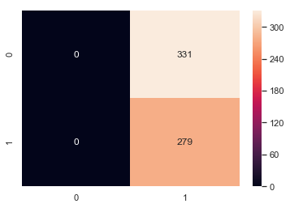

```
0.2

Accuracy Score 0.4754
F1 Score 0.6355

Confusion Matrix
```

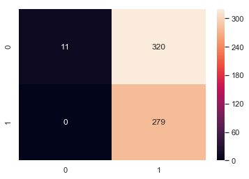

```
0.3

Accuracy Score 0.5131
F1 Score 0.6329

Confusion Matrix
```

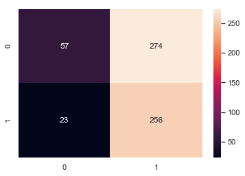

```
0.4

Accuracy Score 0.6066
F1 Score 0.6238

Confusion Matrix
```

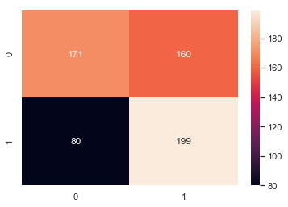

```
0.5

Accuracy Score 0.6426
F1 Score 0.5322

Confusion Matrix
```

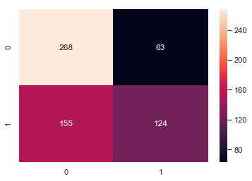

```
0.6

Accuracy Score 0.6262
F1 Score 0.4571

Confusion Matrix
```

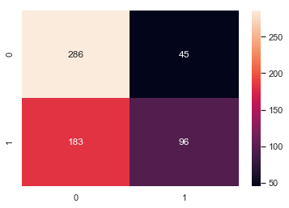

```
0.7

Accuracy Score 0.5787
F1 Score 0.2419

Confusion Matrix
```

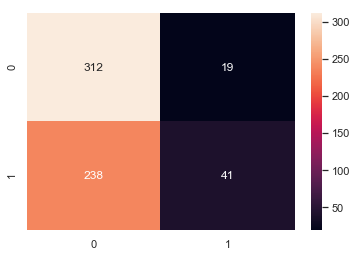

```
0.8

Accuracy Score 0.5443
F1 Score 0.0071

Confusion Matrix
```

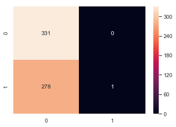

```
0.9

Accuracy Score 0.5426
F1 Score 0.0

Confusion Matrix
```

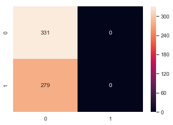

```python
for j in np.arange(0.1,1,0.1):
    custom_prob = j #defining the cut-off value of our choice
    custom_cutoff_data=[]#defining an empty list
    for i in range(0,len(y_train_LDA)):#defining a loop for the length of the test data
        if np.array(pred_prob_train[:,1])[i] > custom_prob:#issuing a condition for our probability values to be
            #greater than the custom cutoff value
            a=1#if the probability values are greater than the custom cutoff then the value should be 1
        else:
            a=0#if the probability values are less than the custom cutoff then the value should be 0
        custom_cutoff_data.append(a)#adding either 1 or 0 based on the condition to the end of the list defined by us
    print(round(j,3),'\n')
    print('Accuracy Score',round(metrics.accuracy_score(y_train_LDA,custom_cutoff_data),4))
    print('F1 Score',round(metrics.f1_score(y_train_LDA,custom_cutoff_data),4),'\n')
    plt.figure(figsize=(6,4))
    print('Confusion Matrix')
    sns.heatmap(metrics.confusion_matrix(y_train_LDA,custom_cutoff_data),annot=True,fmt='.4g'),'\n\n'
    plt.show();
```

```
AUC for the Training Data: 0.669
AUC for the Test Data: 0.655
```

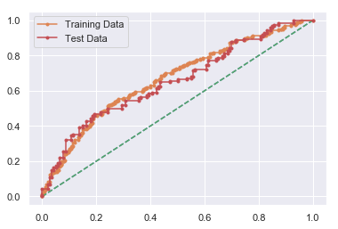

```python
# AUC and ROC for the training data

# calculate AUC
lda_train_auc = metrics.roc_auc_score(y_train_LDA,pred_prob_train[:,1])
print('AUC for the Training Data: %.3f' % lda_train_auc)

#  calculate roc curve
fpr, tpr, thresholds = metrics.roc_curve(y_train_LDA,pred_prob_train[:,1])
plt.plot([0, 1], [0, 1], linestyle='--')
# plot the roc curve for the model
plt.plot(fpr, tpr, marker='.',label = 'Training Data')


# AUC and ROC for the test data

# calculate AUC
lda_test_auc = metrics.roc_auc_score(y_test_LDA,pred_prob_test[:,1])
print('AUC for the Test Data: %.3f' % lda_test_auc)

#  calculate roc curve
fpr, tpr, thresholds = metrics.roc_curve(y_test_LDA,pred_prob_test[:,1])
plt.plot([0, 1], [0, 1], linestyle='--')
# plot the roc curve for the model
plt.plot(fpr, tpr, marker='.',label='Test Data')
# show the plot
plt.legend(loc='best')
plt.show()
```

```python
lda_metrics=classification_report(y_train_LDA, pred_class_train,output_dict=True)
dftra=pd.DataFrame(lda_metrics).transpose()
lda_train_f1=round(dftra.loc["1"][2],2)
lda_train_recall=round(dftra.loc["1"][1],2)
lda_train_precision=round(dftra.loc["1"][0],2)
lda_train_acc=round(dftra.loc["accuracy"][0],2)
print ('lda_train_precision ',lda_train_precision)
print ('lda_train_recall ',lda_train_recall)
print ('lda_train_f1 ',lda_train_f1)
print ('lda_train_f1 ',lda_train_acc)
```

[output not shown]

```python
lda_metrics=classification_report(y_test_LDA, pred_class_test,output_dict=True)
dfte=pd.DataFrame(lda_metrics).transpose()
lda_test_f1=round(dfte.loc["1"][2],2)
lda_test_recall=round(dfte.loc["1"][1],2)
lda_test_precision=round(dfte.loc["1"][0],2)
lda_test_acc=round(dfte.loc["accuracy"][0],2)
print ('lda_train_precision ',lda_test_precision)
print ('lda_train_recall ',lda_test_recall)
print ('lda_train_f1 ',lda_test_f1)
print ('lda_train_acc ',lda_test_acc)
```

[output not shown]

```python
index=['Accuracy', 'AUC', 'Recall','Precision','F1 Score']
data = pd.DataFrame({'LR Train':[lr_train_acc,lr_train_auc,lr_train_recall,lr_train_precision,lr_train_f1],
        'LR Test':[lr_test_acc,lr_test_auc,lr_test_recall,lr_test_precision,lr_test_f1],
       'LDA Train':[lda_train_acc,lda_train_auc,lda_train_recall,lda_train_precision,lda_train_f1],
        'LDA Test':[lda_test_acc,lda_test_auc,lda_test_recall,lda_test_precision,lda_test_f1],},index=index)
round(data,2)
```

[output not shown]

### 2.4 Inference: Basis on these predictions, what are the insights and recommendations.

$Insights :$

$Recommendations :$

To increase more holiday packages for the employee

1. We can provide complimentary breakfast and dinner for the holiday package.
2. Great deals like extra-day stay for the holiday package from the normal trip package.
3. Travel package rewards for the employee performance